# Tutoral de uso de PhyML v3 para selección de modelos y búsquedas intensivas de árboles

[Pablo Vinuesa, CCG-UNAM, Cuernavaca, México](https://www.ccg.unam.mx/~vinuesa/). [GitHub repos](https://github.com/vinuesa); [@pvinmex](https://twitter.com/pvinmex)

2025-08-08

# 1 Selección y análisis de modelos paramétricos y empíricos mediante LRTs, AIC y BIC con phyml, programación AWK, Bash y R

## 1.1 Presentación

Estas prácticas fueron diseñadas originalmente para los [Talleres Internacionales de Bionformática, TIB2022](https://www.nnb.unam.mx/EBM2022/pangenomica-y-filogenomica-microbiana/). Este tutorial está basado en el material del repositorio [GitHub - TIB-filoinfo](https://github.com/vinuesa/TIB-filoinfo).

La versión actual, es una adaptación para el **Tópico selecto de: Introducción al Biocómputo en Sistemas Linux para Genómica**, impartido para alumn@s de la [Facultad de Ciencias - UNAM](https://www.fciencias.unam.mx/) que cursan el N3 del [Taller de Ciencias Genómicas - de Moléculas a Ecosistemas](https://www.ccg.unam.mx/noticias/academicas/taller-de-ciencias-genomicas-de-moleculas-a-ecosistemas/) (semestre 2023-1), impartido en el [Centro de Ciencias Genómicas - UNAM](https://www.ccg.unam.mx/).

El material fue extendido para mi curso en la [Licenciatura en Ciencias Genómicas, LCG-UNAM](https://www.lcg.unam.mx/), incluyendo los $scripts$ [*phyml_DNAmodelFinder.sh*](https://github.com/vinuesa/TIB-filoinfo/blob/master/phyml_DNAmodelFinder.sh) y [*phyml_ProtModelFinder.sh*](https://github.com/vinuesa/TIB-filoinfo/blob/master/phyml_protModelFinder.sh) que acompañan a este tutoral.

## 1.2 Objetivos

En esta práctica aprenderemos a usar $phyml$ para seleccionar **modelos de sustitución, paramétricos (DNA) y empíricos (prot)**, usando **pruebas de cocientes de verosimilitudes ($LTRs$)** y métodos basados en **criterios de información** como los de Akaike ($AIC$) y bayesiano ($BIC$). Usaremos scripts sencillos de $R$ para despliegue gráfico de resultados y análisis numérico de valores de $lnL$ para los modelos en competición.

A lo largo de las prácticas iremos optimizando los comandos usados, agregando $blucles$, $arreglos$, $hashes$ entre otros, para hacer más eficiente el análisis, culminando con la presentación de los $scripts$ *phyml_DNAmodelFinder* y *phyml_protModelFinder*, con los que automatizaremos el proceso. Ambos programas útiles para la investigación en filogenética.

Además, aprenderemos a hacer **búsquedas intensivas** bajo el mejor modelo seleccionado, **usando múltiples árboles de semilla**, así como el despliegue y edición de los mejores árboles encontrados con $FigTree$.

Al concluir el tutorial habrán adquirido una sólida formación en selección de modelos evolutivos para filogenética, y aprendido o reforzado aspectos fundamentales de biocómputo desde la línea de comandos en un entorno de $Linux$.

## 1.3 Licencia

El material del [Taller, TIB-filoinfo](https://www.nnb.unam.mx/EBM2022/pangenomica-y-filogenomica-microbiana/) lo distribuyo públicamente a través de este repositorio GitHub bajo la [**Licencia No Comercial Creative Commons 4.0**](https://creativecommons.org/licenses/by-nc/4.0/)

This work is licensed under a [Creative Commons Attribution-NonCommercial 4.0](http://creativecommons.org/licenses/by-nc/4.0/)

# 2 NOTAS DE INSTALACION DE PHYML DESDE EL REPOSITORIO GitHub

Para correr las prácticas que siguen a continuación es necesario que tengas instalada una versión reciente de $phyml$, idealmente v3.3.20220408.

```
1. Descarga la ultima version estable desde el [repositorio GitHub de phyml](https://github.com/stephaneguindon/phyml/releases)
wget -c  https://github.com/stephaneguindon/phyml/archive/refs/tags/v3.3.20220408.tar.gz

2. desempaqueta y ve al direcotorio
tar -xvzf v3.3.20220408.tar.gz
cd phyml-v3.3.20220408.tar.gz

3. Para compilarlo, ejecuta:

./autogen.sh

./configure

make

4. El binario aparecerá en el subdirecorio src
cd src

./phyml --help

5. Sugiero copiar phyml a un directorio en el $PATH
cp $HOME/bin

# o para instalarlo a nivel del sistema, con poderes de administrador
sudo cp phyml /usr/local/bin
```

## 2.1 Publicaciones clave sobre PhyML

1: Lefort V, Longueville JE, Gascuel O. SMS: Smart Model Selection in PhyML. Mol Biol Evol. 2017 Sep 1;34(9):2422-2424. doi: 10.1093/molbev/msx149. PubMed PMID: 28472384; PubMed Central PMCID: PMC5850602.

2: Criscuolo A. morePhyML: improving the phylogenetic tree space exploration with PhyML 3. Mol Phylogenet Evol. 2011 Dec;61(3):944-8. doi: 10.1016/j.ympev.2011.08.029. Epub 2011 Sep 8. PubMed PMID: 21925283.

3: Guindon S, Dufayard JF, Lefort V, Anisimova M, Hordijk W, Gascuel O. New algorithms and methods to estimate maximum-likelihood phylogenies: assessing the performance of PhyML 3.0. Syst Biol. 2010 May;59(3):307-21. doi: 10.1093/sysbio/syq010. Epub 2010 Mar 29. PubMed PMID: 20525638.

4: Guindon S, Delsuc F, Dufayard JF, Gascuel O. Estimating maximum likelihood phylogenies with PhyML. Methods Mol Biol. 2009;537:113-37. doi: 10.1007/978-1-59745-251-9_6. PubMed PMID: 19378142.

## 2.2 Opciones más usadas de PhyML v3

Notas:

- Phyml requiere alineamientos múltiples de DNA o proteína en formato phylip.
- Puedes usar el $script$ convert_aln_format_batch_bp.pl para interconvertir alineamientos múltiples entre diferentes formatos, incluyendo FASTA, PHYLIP, NEXUS, entre muchos otros.

```
# para ver la ayuda
phyml -help
```

```
# -i input_file
# -d nt|aa
# -b -4 usa SH-like branch support values (-b 100 corre 100 repl de bootstrap)
# -m  PARA NT: (modelo de sustitucion HKY85 (default) | JC69 | K80 | F81 | F84 | TN93 | GTR o definido con modificadores de tasa 012345 (ac ag at cg ct gt)
# -m PARA AA LG (default) WAG | JTT | MtREV | Dayhoff | DCMut | RtREV | CpREV | VT | Blosum62 | MtMam | MtArt | HIVw |  HIVb | custom
# -f frec. de nt [e empirica| m estimada por ML]
# -t ts/tv
# -v prop inv [0,1] o estimarla con e
# -c no. clases para discretizar la funcion gamma
# -a e (estima gamma) -a digito (fija su valor)
# -s (define la busqueda o search) NNI SPR BEST (mejor de ambas)
# --rand_start (inicia busquedas de arboles de adic. sec. aleatorizada)
# --n_rand_starts no. (no. de arboles semilla)
# -o params [tlr|tl|lr|l|r|n] permite optimizar combinaciones de t=topología, l=longitud de ramas, r parámetros de tasas (rates) de modelos; n=ninguno
# -u usertree permite pasarle a phyml un árbol precalculado por el usuario
```

## 2.3 Ejemplos de invocación de PhyML v3 para alineamientos de secuencias de DNA (A) y proteína (B)

```
# A: Ejemplo de corrida para NT; recureda que los modificatodres de tasa indicados con -m se aplican en este orden: (ac ag at cg ct gt)
phyml -i primates.phy -m HKY85 -c 4 -a e -o tlr -s BEST --rand_start --n_rand_starts 5 &> /dev/null

# B: Ejemplo de corrida para AA
phyml -i 10_GDP_eucar_prokar_cluO_prof2prof.faa  -d aa -m WAG -c 4 -a e -v e -s BEST &> /dev/null
```

# 3 SELECCION DE MODELOS PARAMÉTRICOS DE DNA USANDO PHYML - Prácticas

Iniciaremos estas prácticas enfocándonos primeramente en el uso de $phyml$, y en conceptos básicos de la selección de modelos paramétricos. Empezaremos por las **pruebas de cocientes o razones de verosimilitudes ($LRTs$)**.

Una vez familiarizados con el uso de $phyml$ y los conceptos básicos de contraste de hipótesis anidadas mediante $LRTs$, nos enfocaremos a eficientizar el análisis computacional, introduciendo estructuras de programación básicas como *bucles* y *estructuras de datos*.

Esta progresión culmina con la presentación de los $scripts$ *phyml_DNAmodelFinder* y *phyml_protModelFinder*, que automatizan el proceso de selección de modelos de manera eficiente, haciendo un riguroso y exhaustivo análisis de los modelos en competición basado en el **criterio de información bayesiano $BIC$**.

## 3.1 Descarga de secuencias para la práctica

Para iniciar las prácticas, descarga las secuencias desde el [repositorio GitHub del TIB22](https://github.com/vinuesa/TIB-filoinfo).

Lo haremos llamando a $wget$ desde la línea de comandos.

Haz un $cd$ al directorio de trabajo, y desde éste ejecuta el siguiente comando:

```
wget -c https://raw.githubusercontent.com/vinuesa/TIB-filoinfo/master/docs/sesion6_maxima_verosimilitud/phyml_tutorial_data.tgz
```

y confirma que tienes el *tarro comprimido (tgz)*:

```
ls -ltr
```

```
-rw-rw-r-- 1 vinuesa vinuesa 145254 nov 21 19:36 phyml_tutorial_data.tgz
```

```
file phyml_tutorial_data.tgz
```

```
phyml_tutorial_data.tgz: gzip compressed data, last modified: Mon Jul 29 01:29:04 2019, from Unix, original size modulo 2^32 40960
```

el cual puedes desempacar con el siguiente comando:

```
tar -xzf phyml_tutorial_data.tgz
```

## 3.2 Pruebas de razones de verosimilitud ($LRTs$) entre pares de modelos anidados

Las **pruebas de razones o cocientes de verosimilitudes** son una manera natural de evaluar parejas de modelos en competición, en los que comparamos el ajuste relativo de un modelo nulo ($lnL_{H_0}$) y uno alternativo ($lnL_{H_1}$), el cual relaja una o más constricciones en parámetros impuestos por $H_0$. Es decir, compararemos **modelos anidados**, donde:

**LRT=2*($lnL_{H_1}$ - $lnL_{H_0}$)**

El **estadístico $LRT$** se distribuye como una **$\chi^2$** con **$q$ grados de libertad**, donde $q$=diferencia en parámetros libres a estimar entre $H_1$ y $H_0$.

Para acelerar el procedimiento de seleccion de modelos, típicamemente seguiremos los siguientes pasos:

1. Calcular un árbol de distancias NJ, bajo el modelo más sencillo ($JC$), lo cual es muy rápido
2. Este árbol lo usaremos para calcular los valores de los parámetros de los diferentes modelos a ajustar, y determinar la puntuación de verosimilitud de los modelos evaluados

Es decir, recordando la definición de la función de máxima verosimilitud:

`lnL = Pr(D|H)`, que para modelos filogenéticos podemos reescribir como:

**ln*L* = Pr(D|$\tau\nu\rho$)**, donde:

- D=Datos (alineamiento)
- $\tau$=topología
- $\nu$=conjunto de longitudes de rama
- $\rho$= parámetros del modelo de sustitución

Veamos cómo hacerlo en el siguiente ejemplo.

### 3.2.1 Estima del árbol NJ de referencia, sobre el que estimaremos los parámetros de todos los modelos en competición

El objetivo de calcular inicialmente un un árbol NJ (método algorítmico de agrupación muy rápido) es **fijar la topología ($\tau$)**, que es el parámetro más costoso computacionalmente de calcular, pidiendo a $phyml$ que optimice sólo los parámetros de longitud de rama ($\nu$) y del modelo de sustitución ($\rho$) a evaluar (opción `-o lr`), calculando el puntaje ($score$) de verosimilitud correspondiente.

```
# Visualizemos el alineamiento para confirmar que es tal, y que está en formato phylip (requerido por phyml)
head primates.phy && tail primates.phy

# Estima de árbol BioNJ con distancias JC69 (una sola tasa de sustitución e igual frecuencia de bases)
#  phyml -i primates.phy -d nt -m 000000 -f 0.25,0.25,0.25,0.25 -b 0 -c 1 -o n &> /dev/null
phyml -i primates.phy -d nt -m JC69 -b 0 -c 1 -o n &> /dev/null

# Renombremos el archivo
mv primates.phy_phyml_tree.txt primates_JC.ph

# Podemos visualizar el arbol con:
figtree primates_JC.ph &
```

### 3.2.2 Optimización de parámetros y estimas de $lnL$ para una gama de modelos anidados a evaluar

Después de calcular el árbol *NJ-JC*, iniciamos el proceso de seleccion de modelos.

Existen 203 modelos en la familia $GTR+I+G$, los cuales se distinguen por su grado de parametrización con respecto a:

1. frecuencia de bases
2. número de clases de tasas de sustitución
3. modelado de la heterogeneidad de tasas de sustutución entre sitios

**El objetivo de la selección de modelos** es encontrar uno con un **nivel óptimo de parámetros para nuestros datos**. Es decir, un modelo con suficientes parámetros para modelar con realismo las características más salientes de nuestros datos (alineamiento), haciendo uso de **tres clases de parámetros** listados en el párrafo entarior.

La idea es agregar los parámetros necesarios para que el modelo presente un ajuste óptimo, pero sin incurrir en sobreparametrización.

Para entender el proceso, vamos a evaluar una serie de pares de modelos anidados de parametrización creciente, concretamente:

- JC vs K2P
- JC vs F81
- JC vs HKY
- HKY vs HKY+G
- HKY+G vs HKY+G+I

Recordemos cómo especificar la codificación de tasas de sustitución relativas en `phyml`, haciendo uso de los siguientes códigos numéricos:

```
tipo de sust. : Tv Ti Tv Tv Ti Tv
clase de tasas: 0  1  2  3  4  5
sustituciones:  ac ag at cg ct gt
---------------------------------
  A  == G    Ti (purinas)
  || X ||    Tv
  C  == T    Ti (pirimidinas)

donde:
- 000000 ó 111111 representa una sola tasa de sustitución, como en los modelos JC69 o F81
- 121121 ó 010010 representa una clase de tasas para las transiciones (Ti)
                  y otra clase de tasas para las transversiones (Tv), como en K2$ o HKY85
- 012345 representa un modelo de 6 tasas, es decir, el GTR (General Time Reversible).
```

#### 3.2.2.1 Jukes y Cantor de 1969 ($JC$ o $JC69$)

Comencemos la evaluacion de modelos. Empezaremos arbitrariamente por el modelo más sencillo, el JC.

- **Parametrización de JC**: igual frecuencia de bases ($\pi_a = \pi_c = \pi_g = \pi_c = 0.25$ ) y tasa de Ti = Tv ($\alpha = \beta$).
- Este **es el modelo nulo por excelencia**, es decir, el que impone restricción total a los parámetros de tasa y frecuencia.

```
# 1. Modelo JC
phyml -i primates.phy -d nt -m JC69 -c 1 -b 0 -u primates_JC.ph -o lr &> /dev/null

# Anotemos el valor de Log-likelihood para este modelo
cat primates.phy_phyml_stats.txt
```

```
...truncado
. Sequence filename:            primates.phy
. Data set:                 #1
. Initial tree:             user tree (primates_JC.ph)
. Model of nucleotides substitution:    JC69
. Number of taxa:           12
. Log-likelihood:           -6424.20245 <=== ESTE ES EL PUNTAJE (lnL) QUE NECESITAMOS
. Unconstrained log-likelihood:     -4184.81795
. Composite log-likelihood:         -14938.70804
. Parsimony:                1153
. Tree size:                1.43328
. Discrete gamma model:         Yes
  - Number of classes:          1
  - Gamma shape parameter:      1.000
  - Relative rate in class 1:       1.00000 [freq=1.000000]
. Nucleotides frequencies:
  - f(A)=  0.25000
  - f(C)=  0.25000
  - f(G)=  0.25000
  - f(T)=  0.25000
...truncado
```

Trabajando desde un $shell$ de $Unix$ o $linux$, podemos acceder a este valor sin necesidad de abrir el archivo:

```
# o usando grep:
grep Log-like primates.phy_phyml_stats.txt
```

```
. Log-likelihood:           -6424.20245
```

Guardaremos el valor de $lnL$ para cada uno de los modelos a evaluar en un archivo adecuadamente nombrado para posterior referencia.

```
grep Log-like primates.phy_phyml_stats.txt > JC.fit
```

También podríamos haber usado $awk$, que nos permite encontrar la línea que contiene ‘Log-like’, y además imprimir el último campo de la misma, que contiene el valor que buscamos.

```
awk '/Log-like/{print $NF}' primates.phy_phyml_stats.txt
```

```
-6424.20245
```

#### 3.2.2.2 El modelo de Kimura de 1980 ($K80$) o Kimura de 2 parámetros ($K2P$)

- **Parametrizacaión de K80**: asume igual frecuencia de bases ($\pi_a = \pi_c = \pi_g = \pi_c = 0.25$ ), pero permite acomodar Ti $\ne$ Tv ($\alpha \ne \beta$).
- Con este modelo evaluamos si existe un *sesgo transicional* en los datos

```
# 2. Modelo K80; veamos lo que tarda al usar el "user-tree" vs. tener que estimarlo
#phyml -i primates.phy -d nt -m 010010 -f 0.25,0.25,0.25,0.25 -t e -c 1 -u primates_JC.ph -o lr -b 0 &> /dev/null
phyml -i primates.phy -d nt -m K80 -t e -c 1 -u primates_JC.ph -o lr -b 0 &> /dev/null

grep Log- primates.phy_phyml_stats.txt > K80.fit
```

#### 3.2.2.3 Modelo de Felsenstein de 1981 ($F81$)

- **Parametrización**: acomoda diferentes frecuencias de bases ($\pi_a \ne \pi_c \ne \pi_g \ne \pi_c$) pero asume que la tasa de Ti = Tv ($\alpha = \beta$).
- Con este modelo evaluamos si existe *sesgo composicional*, evaluando frecuencias bajo máxima verosimilitud `-f m`.

```
# 3. Modelo F81
# phyml -i primates.phy -d nt -m 000000 -f m -c 1 -u primates_JC.ph -o lr -b 0 &> /dev/null
phyml -i primates.phy -d nt -m F81 -f m -c 1 -u primates_JC.ph -o lr -b 0 &> /dev/null

grep Log- primates.phy_phyml_stats.txt > F81.fit
```

#### 3.2.2.4 Modelo de Hasegawa, Kishino y Yano de 1985 ($HKY85$)

- **Parametrización**: acomoda diferentes frecuencias de bases ($\pi_a \ne \pi_c \ne \pi_g \ne \pi_c$) y tasa de Ti $\ne$ Tv ($\alpha \ne \beta$).
- Con este modelo evaluamos si existe *sesgo composicional* de bases y *sesgo transicional* en tasas de sustitución.

```
# 4. Modelo HKY85
# phyml -i primates.phy -d nt -m 010010 -f m -t e -c 1 -u primates_JC.ph -o lr -b 0 &> /dev/null
phyml -i primates.phy -d nt -m HKY85 -f m -t e -c 1 -u primates_JC.ph -o lr -b 0 &> /dev/null

grep Log-like primates.phy_phyml_stats.txt > HKY85.fit
```

NOTA: Como veremos en ejemplos posteriores, podíamos haber optimizado el proceso corriendo un `bucle for` como el mostrado abajo. Por ahora nos concetramos en entender cómo llamar a $phyml$ con modelos de parametrización creciente.

```
for m in JC69 K80 F81 HKY85; do
  phyml -i primates.phy -d nt -m $m -f m -u primates_JC.ph -c 1 -o lr -b 0 &> /dev/null
  awk '/Log-like/{print $NF}' primates.phy_phyml_stats.txt > ${m}.fit
done
```

#### 3.2.2.5 Modelo de Hasegawa, Kishino y Yano de 1985 + distribución Gamma ($HKY85+G$)

- **Parametrización**: ($\pi_a \ne \pi_c \ne \pi_g \ne \pi_c$), Ti $\ne$ Tv ($\alpha \ne \beta$) y distribución Gamma ($+\Gamma$) para acomodar heterogeneidad de tasas entre sitios o columnas del alineamiento
- Con este modelo podemos evaluar si existe *sesgo composicional* de bases, *sesgo transicional* en tasas de sustitución y *heterogeneidad de tasas entre sitios*.

```
# 5. Modelo HKY85+G
# phyml -i primates.phy -d nt -m 121121 -f m -t e -c 4 -a e -u primates_JC.ph -o lr -b 0 &> /dev/null
phyml -i primates.phy -d nt -m HKY85 -f m -t e -c 4 -a e -u primates_JC.ph -o lr -b 0 &> /dev/null
grep Log-like primates.phy_phyml_stats.txt > HKY85G.fit
```

#### 3.2.2.6 Modelo de Hasegawa, Kishino y Yano de 1985 + proporción de sitios invariantes ($HKY85+I$)

- **Parametrización**: ($\pi_a \ne \pi_c \ne \pi_g \ne \pi_c$), Ti $\ne$ Tv ($\alpha \ne \beta$) y proporción de sitios invariantes ($+I$) para acomodar heterogeneidad de tasas entre sitios o columnas del alineamiento
- Con este modelo podemos evaluar si existe *sesgo composicional* de bases, *sesgo transicional* en tasas de sustitución y *heterogeneidad de tasas entre sitios*, considerando sólo una proporción de sitios invariantes.

```
# 5. Modelo HKY85+I
# phyml -i primates.phy -d nt -m 121121 -f m -t e -c 1 -v e -u primates_JC.ph -o lr -b 0 &> /dev/null
phyml -i primates.phy -d nt -m HKY85 -f m -t e -c 1 -v e -u primates_JC.ph -o lr -b 0 &> /dev/null
grep Log-like primates.phy_phyml_stats.txt > HKY85I.fit
```

#### 3.2.2.7 Modelo de Hasegawa, Kishino y Yano de 1985 + distribución Gamma + proporción de sitios invariantes ($HKY85+G+I$)

- **Parametrización**: ($\pi_a \ne \pi_c \ne \pi_g \ne \pi_c$), Ti $\ne$ Tv ($\alpha \ne \beta$), distribución Gamma ($+\Gamma$) y proporción de sitios invariantes ($pInv$) para modelar heterogeneidad de tasas entre sitios
- Con este modelo podemos evaluar si existe *sesgo composicional* de bases, *sesgo transicional* en tasas de sustitución, *heterogeneidad de tasas entre sitios*, asumiendo además una *proporción de sitios invariantes*.

```
# 6. Modelo HKY85+G+I
#  phyml -i primates.phy -d nt -m 121121 -f m -t e -c 4 -a e -v e -u primates_JC.ph -o lr -b 0 &> /dev/null
phyml -i primates.phy -d nt -m HKY85 -f m -t e -c 4 -a e -v e -u primates_JC.ph -o lr -b 0 &> /dev/null
grep Log-like primates.phy_phyml_stats.txt > HKY85GI.fit
```

**Nota:** en el ejercicio de selección de matrices de sustitución para proteínas veremos cómo optimizar este tedioso proceso, haciendo uso de un $bucle\ for$ y un $hash$ para guardar los valores de $lnL$ directamente en una estructura de datos, sin escribir archivos intermedios, como hicimos en los ejemplos anteriores.

### 3.2.3 Análisis gráfico y estadístico de resultdos usando herramientas de $Linux$ y $R$

Una vez evaluados los diferentes modelos en competición, haremos un simple análisis gráfico y estadístico de los resultados.

- Parseo de valores $lnL$ de los archivos *.fit, y generación de archivos tsv y csv

```
# generemos un archivo separado por tabuladores con su cabecera
awk 'BEGIN{OFS="\t"; print "model\tlnL"}{print FILENAME , $NF}' *.fit | sed 's/\.fit//' > model_fits.tsv

# limpiemos un poco el directorio de trabajo
rm *fit
```

Visualizemos los resultados obtenidos, ordenados de mayor a menor $lnL$ con `sort -grk2`

```
# sort -g, --general-numeric-sort: compare according to general numerical value
sed '1d' model_fits.tsv | sort -grk2 | column -t
```

```
HKY85G   -5711.93899   <== mejor (mayor) lnL
HKY85GI  -5711.94038
HKY85I   -5768.00412
HKY85    -5981.72029
K80      -6142.42909
F81      -6284.99565
JC69     -6424.20245
```

Los resultados arriba mostrados indican que el mejor modelo es $HKY+G$. Noten que en este caso existe una **interacción negativa** entre los parámetros $\Gamma$ e $I$ en el modelo $HKY+G+I$, ya que este último tiene un puntaje de $lnL$ ligeramente más bajo que el del modelo $HKY+G$, a pesar de contar con un parámetro más.

Esta interacción negativa entre $\Gamma$ y $I$ la he observado con cierta frecuencia, por lo que suelo ignorar $I$ para modelar la heterogeneidad de tasas entre sitios, a no ser que la evidencia en favor de usar $I$ sea contundente.

#### 3.2.3.1 Graficado con R de valores de verosimilitud de los modelos en competición, ordenados de $lnL$

```
# 6. Evaluacion del merito relativo de los modelos HKY85+G vs HKY85+G+I
#    mediante la prueba de cocientes de verosimilitud (LRT), en R

# carga R
R

# leamos los datos en una estructura tipo dataframe
# system("ls")
list.files(pattern="\\.tsv$")
dfr <- read.csv(file="model_fits.tsv", header = TRUE, sep="\t")

# ver la estructura del data frame
str(dfr)

# imprimelo a pantalla
head(dfr)

# 6.2 veamos una grafica tipo "dotchart". Que puedes concluir?
dfrord <- dfr[order(dfr$lnL),]
dfrord
dotchart(dfrord$lnL, labels = dfrord$model, main = "sorted model scores", xlab="lnL score")

# guardemos salida como archivo png
png(file="LRTs_primates_dotchart.png")
dotchart(dfrord$lnL, labels = dfrord$model, main = "sorted model scores", xlab="lnL score")
dev.off()
```

- visualizemos la gráfica

```
eog LRTs_primates_dotchart.png &
```

[figure not shown]

**Figura 1.** *Dotchart* mostrando resultados ordenados de puntuación de $lnL$ para los modelos indicados, estimados sobre una filogenia $NJ-JC$, y el alineamiento *primates.phy*.

La gráfica revela claramente la importancia los parámetros de **frecuencia de bases**, **ti/tv** y **heterogeneidad de tasas entre sitios modelada con una distribución gamma ($\Gamma$)**, reflejados en los incrementos altamente significativos de $lnL$ de los modelos de complejidad creciente analizados.

#### 3.2.3.2 Evaluación formal de ajuste relativo entre pares de modelos anidados con grado creciente de parametrización, mediante **pruebas de razones de verosimilitud** ($LRTs$)

Examinando la **figura 1**, vemos que los modelos **$JC69$** y **$F81$** tienen puntajes de verosimilitud muy distintos. La pregunta es: ¿Son significativamente distintos?. Vamos a hacer una **prueba de cocientes de verosimilitudes** o $LRT$ para evaluar estadísticamente si existe un sesgo significativo en **frecuencia de baes** ($-f\ e$), que justifique estimar tres parámetros libres adicionales (por $F81$).

Recordemos que:

1. Las pruebas de razones de verosimilitud ($LRTs$) sólo permiten **comparar parejas de modelos anidados**, en los que el **modelo nulo ($L_{H_0}$) está anidado dentro del alternativo ($L_{H_1}$)**, es decir, $L_0$ es un caso particular de $L_1$.
2. El estadístico $LRT=2*(lnL_1 - lnL_0)$ sigue una distribución $\chi^2$ (chi-cuadrada):

$$\chi^2 = \sum \frac {(O -
E)^2}{E}$$

```
# 6.3 Entre los dos modelos que parecen empatados, veamos si existen o no diferencias significativas,
#     corriendo una prueba estadistica formal: dado que los modelos JC69 y F81 estan anidados,
#     podemos correr un simple LRT (prueba de razones de verosimilitudes): LRT = 2(lnL1 - lnL 0)
dfr

# LRT = 2(   lnL1    -    lnL0  )
# 2 veces la diferencia de lnL entre el alternativo (F81) - modelo nulo (JC69)
xsq <- 2*(-6284.99565 - -6424.20245)
xsq # [1] 278.4136 # Este es un valor gigantesco de la ji-cuadrada, y por tanto ALTAMENTE SIGNIFICATIVO.

# cómputo de estadísticas
pchisq(xsq,3)      # 1;  este es el valor critico de la X2 para el estadistico LRT con 3 grados de libertad; [1] 1
1-(pchisq(xsq,3))  # 0; esta es la p asociada a dicho valor crítico, ABSOLUTAMENTE SIGNIFICATIVA =>
                   # rechazamos el modelo nulo

q()         # para salir de R
            # decimos que NO quieren salvar sesion
```

En general, cuando observamos una diferencia de $lnL$ de decenas de unidades entre modelos anidados, la diferencia será significativa, como podrás comprobar en el siguiente ejercicio:

- **Tarea**: repite el ejercicio de evaluación de cocientes de similitud para las siguientes parejas de modelos anidados:
  - K80 vs. HKY85 (¿qué evaluamos con este contraste de hipótesis, y los dos que siguen?)
  - HKY85+I vs. KY85+I+G

### 3.2.4 Estima de la filogenia bajo el mejor modelo encontrado: HKY85+G

Estimemos la filogenia de máxima verosimilitud bajo el modelo seleccionado: $HKY+G$

Nótese que **usamos sólo la parameterización del modelo seleccionado** (`-m HKY85 -c 4 -a e`), pero no los varlores de los parámetros, ya que fueron optimizados sobre el árbol $NJ-JC$.

Pediremos a *phyml* que optimice todos los parámetros, incluyendo ahora la *topología*, *longitudes de ramas* y *parámetros del modelo de sustitución* con la opción

```
-o
tlr
```

.

- **Pregunta**: ¿qué tipo de rearreglos de rama usa $phyml$ en la llamada mostrada seguidamente?

```
phyml -i primates.phy -d nt -m HKY85 -f m -t e -c 4 -a e -o tlr
```

Una vez terminada la búsqueda, veamos las estimas de máxima verosimilitud de los parámetros del modelo de sustitución HKG+G.

```
# veamos las estimas de máxima verosimilitud de los parámetros del modelo de sustitución HKG+G
cat primates.phy_phyml_stats.txt
```

```
...truncado
. Sequence filename:            primates.phy
. Data set:                 #1
. Initial tree:             BioNJ
. Model of nucleotides substitution:    HKY85
. Number of taxa:           12
. Log-likelihood:           -5711.93881
. Unconstrained log-likelihood:     -4184.81795
. Composite log-likelihood:         -14275.02293
. Parsimony:                1153
. Tree size:                3.38341
. Discrete gamma model:         Yes
  - Number of classes:          4
  - Gamma shape parameter:      0.363
  - Relative rate in class 1:       0.01179 [freq=0.250000]
  - Relative rate in class 2:       0.15381 [freq=0.250000]
  - Relative rate in class 3:       0.68822 [freq=0.250000]
  - Relative rate in class 4:       3.14618 [freq=0.250000]
. Transition/transversion ratio:    12.726587
. Nucleotides frequencies:
  - f(A)=  0.36372
  - f(C)=  0.31987
  - f(G)=  0.08153
  - f(T)=  0.23488
...truncado
```

Compara estos parámetros con los obtenidos durante el proceso de selección de modelos usando el árbol $NJ-JC$. ¿Notan diferencias?

Los resultados de estimas de máxima verosimilitud de los parámetros del modelo $HKY+G$ arriba mostrados (del archivo primates.phy_phyml_stats.txt) son fáciles de entender, pero:

- **Pregunta**: ¿qué significan los valores “Relative rate in class 1 - 4”?

### 3.2.5 Despliegue y edición del árbol con figtree

Podemos desplegar y editar los árboles con [figtree](https://github.com/rambaut/figtree/releases) del [Prof. Andrew Rambaut](http://tree.bio.ed.ac.uk/).

```
# despliega el árbol:
figtree primates.phy_phyml_tree.txt &
```

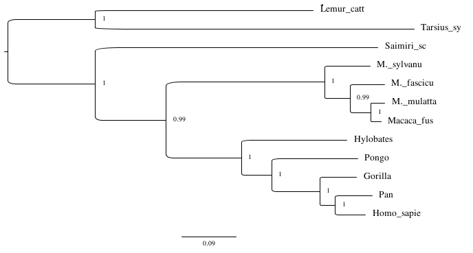

**Figura 2.** Mejor árbol de máxima verosimilitud encontrado para primates.phy bajo el modelo $HKY+G$, seleccionado mediante **LRTs**

## 3.3 Estrategia alternativa de selección de modelos de DNA: reducción de parámetros del modelo GTR+G+I, y evaluación de los modelos resultantes mediante $AIC$

En el ejercicio anterior evaluamos una serie de modelos anidados, iniciando arbitrariamente por el más sencillo (JC69), progresando hasta el modelo $HKY85+I+G$.

Pero podríamos haber construido y analizado otras jerarquías de modelos anidados, lo cual, posiblemente, nos hubiera llevado a seleccionar otros modelos. Esta es una limitación de las pruebas de cocientes de verosimilitudes.

Una alternativa es ajustar el modelo más rico en parámetros $GTR+G+I$ (10 parámetros libres: 3 de frecuencias de bases + 5 de tasas + 1 de gamma + 1 de propInv) a los datos, y examinar la matriz de transición resultante para simplificarla (reducir parámetros) donde parezca obvio, por ser tasas muy similares (< ~20-30 % de diferencia), y evaluar los ajustes de estos modelos usando **criterios de información**.

### 3.3.1 Ajuste de modelo $GTR+G+I$ a primates.phy

Igual que en ejemplos anteriores, usamos el árbol NJ-JC para estimar sobre éste los parámetros del modelo de sustitución y evaluar el ajuste ($lnL$) resultante, sin necesidad de invertir tiempo de cómputo en reestimar la topología y longitudes de rama.

Con $grep$ filtramos la línea con el ‘Log-likelihood’ y la guardamos en un archivo adecuadamente nombrado.

```
# GTR+G+I
phyml -i primates.phy -m GTR -a e -f m -v e -u primates_JC.ph -b 0 -o lr
grep Log-like primates.phy_phyml_stats.txt > GTRGI.fit

# visualizamos las tasas del modelo GTR+G+I
grep '<->' primates.phy_phyml_stats.txt
```

```
# GTRIG                 2   3    3   4 rates << clases de tasas para modelos simplificados de 5 y 4 tasas
  A <-> C    3.60550    0   0    0   0
  A <-> G   43.95008    1   1    1   1
  A <-> T    3.05954    0   0    0   0
  C <-> G    2.37102    0   0    0   2
  C <-> T   34.89961    1   2    1   1
  G <-> T    1.00000    0   0    2   3
```

### 3.3.2 Evaluación de modelos simplificados de 2, 3 y 4 tasas

En base a los resultados arriba mostrados, vamos a evaluar modelos alternativos con menos parámetros libres.

La simplificación más obvia es igualar ambas tasas de transiciones, ya que son muy parecidas entre sí y alrededor de un órden de magnitud más altas que las de transversiones.

Evaluaremos otras opciones de simplificación o reducción de número de tasas, como se indica en las columnas numéricas mostradas arriba, junto a las tasas del $GTR+I+G$

Copia el siguiente bloque completo en la terminal para ejecutar todos los comandos secuencialmente.

```
# Evaluación del modelo alternativo (simplificado) de 2 tasas (010010) + G # NOTA: es el HKY85+G
phyml -i primates.phy -m HKY85 -f m -a e -u primates_JC.ph -b 0 -o lr &> /dev/null
grep Log- primates.phy_phyml_stats.txt > model_HKY85G.fit

phyml -i primates.phy -m TN93 -f m -a e -u primates_JC.ph -b 0 -o lr &> /dev/null
grep Log- primates.phy_phyml_stats.txt > model_TN93G.fit

# Visualicemos los ajustes, ordenados por valores decrecientes de lnL:
for f in *fit; do echo -ne "$f\t"; cat $f; done | awk '{print $1,$4}' \
 | sed 's/\.fit//' | sort -k2 | column -t
```

```
GTRGI          -5708.92372
TN93G          -5710.55182
HKYG           -5711.93899
```

Usemos el **criterio de información de Akaike (AIC)** para evaluar estos resultados formalmente.

### 3.3.3 Cálculo de los $AICi$ (de cada modelo) y $\Delta_i$ con respecto al $AICmin$ en `R`

Recordemos la fórmula del **criterio de información de Akaike** para un modelo particular: $AIC_i=-2*(lnL_i)+(2N_i)$

donde:

- $lnL_i=log-Likelihood\ del\ modelo\ i$
- $N_i=número\ de\ parámetros\ libres\ del\ modelo\ i$,

- $N_i=número\ de\ parámetros\ libres\ del\ modelo\ i + (2n - 3)$

```
R

# cálculo del número de ramas libres, donde n=12 taxa
n <- 12 # número de secuencias o nodos terminales
nbranches <- 2*(n-3) # número de ramas libres a estimar para n secuencias

# construyamos el dataframe model_AICs, con los vectores "model" y "AIC"
# vector model con los nombres de los modelos
model <- c("AIC_GTRGI", "AIC_TN93T", "AIC_HKYG")

AIC_GTRGI <- -2*(-5708.92372) + 2*(10+nbranches)
AIC_TN93G <- -2*(-5710.55182) + 2*(7+nbranches)
AIC_HKYG <- -2*(-5711.93898) + 2*(6+nbranches)


# vector AIC, con los AICi de cada modelo, en el mismo orden.
AIC <- c(AIC_GTRGI, AIC_TN93G, AIC_HKYG)

# el dataframe
model_AICs <- data.frame(model, AIC)
model_AICs

# mejor ordenado por valor de AIC
model_AICs[order(model_AICs$AIC),]

# y guardamos en AIC_min
AICmin <- min(model_AICs$AIC)
AICmin
```

```
model_AICs[order(model_AICs$AIC),]
      model      AIC
2 AIC_TN93G 11471.10
3  AIC_HKYG 11471.88
1 AIC_GTRGI 11473.85
```

Construyamos un nuevo $data\ fame$ $model\_deltas$ con los vectores $models$ y $deltas$, con los valores de $\Delta_i$ para cada modelo, con respecto al $AIC\_min$

```
# compute deltas
delta_GTRGI <- AIC_GTRGI - AICmin
delta_HKYG <- AIC_HKYG - AICmin
delta_TN93G <- AIC_TN93G - AICmin

# build vectors
deltas <- c(delta_GTRGI, delta_HKYG, delta_TN93G)
models <- c("GTRGI","HKYG", "TN93G")

# build and print model_deltas data frame
model_deltas <- data.frame(models, deltas)
model_deltas[order(model_deltas$deltas),]
```

```
  models  deltas
3  TN93G 0.00000
2   HKYG 0.77432
1  GTRGI 2.74380
```

### 3.3.4 Conclusiones

- El mejor modelo (AICmin) evaluado es **TN93G (0100020)**, pero el modelo **HKYG (0100010)** es un serio competidor, ya que está a una distancia $\Delta_i\ =\ 0.77$.
- El parámetro de $pInv$ es perfectamente prescindible, y un modelo de 2 o tres tasas parece suficiente para obtener un buen ajuste.
- Queda claro que, si bien el modelo $GTR+G+I$ presenta el valor más alto de $lnL$, al ponderar los parámetros libres a estimar, resulta ser el peor modelo de los evaluados por AIC ($\Delta_i\ =\ 2.74$), indicando que está claramente sobre-parametrizado.

En mi experiencia, esta estrategia es buena por dos motivos:

1. es muy rápida (posiblemente la más rápida)
2. encuentra muy buenos modelos, ya que los métodos tradicionales, incluyendo estrategias automáticas, como las implementadas en $jModelTest2$, no evalúan por defecto a los 203 modelos posibles de la familia $GTR+G+I$ (aunque es posible con la opción `-s 203`).

Para una implementación eficiente de la estrategia arriba descrita, habría que escribir un $script$ para automatizarla.

### 3.3.5 Tarea de ajuste de modelos paramétricos mediante criterios de información AIC y BIC

1. Evalúa mediante AICs las otras simplificaciones en las clases de transversiones propuestas en el esquema de tasas del modelo $GTR+I+G$.
2. Compara los puntajes de $lnL$ de todos estos modelos entre sí mediante análisis de $\Delta_i$, incluyendo los modelos $HKY+G$ y $TN93G$ evaluados previamente.
3. Como veremos en la siguiente sección, el criterio de información de Akaike $AIC$ tiende a seleccionar modelos más parametrizados que el criterio de información bayesiano $BIC$ que presentaremos en la siguiente sección. Repite el análisis usando $BIC$.

# 4 Cálculo de $AICs$ y $BICs$ para selección modelos de aminoácidos

Recuerden que para la inferencia de **filogenias de proteínas** bajo *máxima verosimilitud* se usan **matrices empíricas de sustitución**, como la $BLOSUM62$ o $JTT$ … Dado que estas matrices NO están anidadas entre sí, necesitamos usar **criterios de información** como el $AIC$ o $BIC$ para evaluar su mérito o ajuste relativo.

En el siguiente ejercicio evaluaremos diversas matrices empíricas, ajustando o no frecuencia de los residuos ($-f\ e$), y/o distribución gamma ($+G$) para modelado de la heterogeneidad de tasas entre los sitios o columnas del alineamiento.

Como hicimos en ejemplos anteriores, para minimizar el tiempo de cómputo, estimaremos un un árbol NJ-LG, el cual pasaremos a $phyml$ como filogenia pre-definida por el usuario (`-u usertree`).

Copia todo el bloque en la terminal, a partir de `infile=primates_21_AA.phy`, para ejecutar todas las líneas secuencialmente.

## 4.1 Evaluación rápida de un subconjunto de matrices con un $bucle\ for$

En este ejercicio haremos uso más eficiente de las herramientas que nos brindan el $Shell$ y $linux$, como primeros pasos hacia la automatización del proceso.

```
# Evaluemos un subconjunto de los modelos empiricos (matrices de sustitución) implementados en phyml para proteínas
# - Amino-acid based models : LG (default) | WAG | JTT | MtREV | Dayhoff | DCMut | RtREV | CpREV | VT | AB
#                     Blosum62 | MtMam | MtArt | HIVw |  HIVb | custom

# primero seleccionemos la mejor matriz de base y además ajustando con ajuste empírico de frecuencias y
#   una distribución gamma para modelar heterogeneidad de tasas entre sitios
# NOTA: copia todo el bloque, hasta pasado el done, y pégalo en tu consola

# guardemos el archivo de entrada en una variable
infile=primates_21_AA.phy

# primero estimemos un árbol de distancias NJ-LG, de cómputo rápido
phyml -i "$infile" -d aa -m LG -c 1 -b 0 -o n &> /dev/null

# y renombrémoslo, para su uso como ´usertree'
mv "${infile}"_phyml_tree.txt primates_LG.ph

# verifica que se generó el archivo;
# si no fuera el caso, termina el proceso con mensaje explícito de error
[[ ! -s primates_LG.ph ]] && { echo "ERROR: primates_LG.ph not found"; exit 1 ; }

# declaramos el hash model_fits para guardar los valores de lnL asociados a cada modelo
declare -A model_scores

# Corramos las matrices derivadas de genes nucleares en un bucle for para un procesado más eficiente
# A las matrices de base le agregamos sucesivamente parámetros adicionales: -a e; -f e; -f m -a e
# Noten el uso de awk para procesar directamente los valores de lnL de los archivos *_phyml_stats.txt,
#   los cuales se guardan en el hash model_scores, usando como llave el nombre del modelo :)
for mat in AB BLOSUM62 DAYHOFF JTT LG VT WAG; do
     echo " >>> running: phyml -i ${infile} -d aa -m $mat -u primates_LG.ph -c 1 -v 0 -o lr &> /dev/null"
     phyml -i ${infile} -d aa -m $mat -f m -u primates_LG.ph -c 1 -o lr &> /dev/null
     model_scores["$mat"]=$(awk '/Log-like/{print $NF}' ${infile}_phyml_stats.txt)

     echo " >>> running: phyml -i ${infile} -d aa -m $mat -c 4 -a e -u primates_LG.ph -o lr &> /dev/null"
     phyml -i ${infile} -d aa -m $mat -f m -c 4 -a e -u primates_LG.ph -o lr &> /dev/null
     model_scores["${mat}+G"]=$(awk '/Log-like/{print $NF}' ${infile}_phyml_stats.txt)

     # noten el uso de '-f e' para estimar las frequencias empíricas de los aminoácidos del alineamiento
     echo " >>> running: phyml -i ${infile} -d aa -m $mat -f m -c 1 -u primates_LG.ph -o lr &> /dev/null"
     phyml -i ${infile} -d aa -m $mat -f e -c 1 -u primates_LG.ph -o lr &> /dev/null
     model_scores["${mat}+f"]=$(awk '/Log-like/{print $NF}' ${infile}_phyml_stats.txt)

     echo " >>> running: phyml -i ${infile} -d aa -m $mat -f e -a e -u primates_LG.ph -o lr &> /dev/null"
     phyml -i ${infile} -d aa -m $mat -f e -c 4 -a e -u primates_LG.ph -o lr &> /dev/null
     model_scores["${mat}+f+G"]=$(awk '/Log-like/{print $NF}' ${infile}_phyml_stats.txt)
done
```

## 4.2 Análisis gráfico y numérico de resultados de $AIC$ usando herramientas de filtrado de $Linux$ y $R$

Primero escribiremos en un archivo los valores de $lnL$ para cada modelo evaluado guardados en nuestro `hash model_scores`, el cual leeremos en $R$ para generar las gráficas de puntuaciones de $lnL$ y calcular los $AIC_i$ de cada modelo.

```
# vamos a recorrer el hash model_scores para imprimir los resultados en forma tabular
#   y ordenada por valores decrecientes de lnL
echo "# writing ${infile}_sorted_model_fits.tsv, sorted by lnL"
for m in "${!model_scores[@]}"; do
    echo -e "$m\t${model_scores[$m]}"
done | sort -bk2 > "${infile}"_sorted_model_fits.tsv

# si se generó el archivo, y no está vacío, lo imprimimos a STDOUT
[[ -s "${infile}"_sorted_model_fits.tsv ]] && cat "${infile}"_sorted_model_fits.tsv

# es trivial generar también un archivo con campos delimitados por comas (csv)
sed 's/\t/,/' "${infile}"_sorted_model_fits.tsv > "${infile}"_sorted_model_fits.csv

# visualizemos la tabla
column -t -s $',' "${infile}"_sorted_model_fits.csv
```

```
JTT+f+G       -4778.48904
AB+f+G        -4814.44420
JTT+G         -4815.80148
JTT+f         -4865.61699
WAG+f+G       -4870.83180
VT+f+G        -4880.25893
JTT           -4904.05775
AB+G          -4910.17657
WAG+G         -4910.24192
LG+f+G        -4913.60180
VT+G          -4916.81421
DAYHOFF+f+G   -4920.31326
AB+f          -4933.84484
LG+G          -4946.47152
WAG+f         -4961.23284
VT+f          -4968.11339
DAYHOFF+G     -4969.87622
BLOSUM62+f+G  -4976.30876
WAG           -4998.94774
BLOSUM62+G    -5002.18584
VT            -5004.20867
LG+f          -5008.95318
DAYHOFF+f     -5021.06263
AB            -5040.59363
LG            -5042.35342
DAYHOFF       -5069.90036
BLOSUM62+f    -5071.35214
BLOSUM62      -5097.14921
```

- ¿Qué podemos concluir de esta salida con respecto a las matrices y parámetros adicionales?

### 4.2.1 Análisis gráfico con R de modelos ordenados por valor de $lnL$

```
# carga R
R

# 6.1 leamos los datos en una estructura tipo dataframe
list.files(pattern='\\.csv')
dfr <- read.csv(file="primates_21_AA.phy_sorted_model_fits.csv", header = FALSE)

# ver la estructura del data frame
str(dfr)

# imprimelo a pantalla
dfr

# aniadimos un header (nombramos las columnas con las variables)
names(dfr) <- c("model", "lnL")
head(dfr)

# veamos un dotchart()
dfrord <- dfr[order(dfr$lnL),]
dotchart(dfrord$lnL, labels = dfrord$model, main = "sorted model scores", xlab="lnL score")

# guardémoslo como pdf
pdf(file="dotchart_sorted_model_scores_for_primates_21_AA.pdf")
dotchart(dfrord$lnL, labels = dfrord$model, main = "sorted model scores", xlab="lnL score")
dev.off()

#  guardémoslo como png
png(file="dotchart_sorted_model_scores_for_primates_21_AA.png")
dotchart(dfrord$lnL, labels = dfrord$model, main = "sorted model scores", xlab="lnL score")
dev.off()
```

- Veamos la gráfica resultante de modelos ordenados por sus valores de $lnL$

```
eog dotchart_sorted_model_scores_for_primates_21_AA.png &
```

[figure not shown]

**Figura 4.** Puntaciones de máxima verosimilitud para los modelos evualuados usando un árbol $NJ-LG$ con el alineamiento $primates\_21\_AA.phy$

```
# veamos los resultados ordenados por valor decreciente de lnL
dfr[order(dfr$lnL, dfr$model, decreasing = TRUE), ]
```

```
# ... truncado
         model       lnL
14      JTT+f+G -4778.489
2        AB+f+G -4814.444
16        JTT+G -4815.801
13        JTT+f -4865.617
26      WAG+f+G -4870.832
22       VT+f+G -4880.259
15          JTT -4904.058
4          AB+G -4910.177
28        WAG+G -4910.242
# ... truncado
```

- **Pregungas**
  - ¿Qué podemos concluir de estos resultados?
  - ¿Usarían $JTT+f+G$ como el mejor modelo?

### 4.2.2 Cálculo formal de $AIC_{min}$ y $\Delta_{AIC_{i}}$ para los modelos en competición

```
# Computo de AICmin y deltaAICi
# recuerda: AICi = 2Ki - 2(lnLi); donde Ki = numero parametros libres del modelo i; lnLi = lnL del modelo i
# número de ramas libres a estimar = 2(n-3)

# G.L:
# - 19 para los 20 AAs (estimo 19 frecuencias y la 20ava es 1-(sum(19 freqs estimadas)))
# - 1  para el parametro alpha de la distriucion gamma
# - 39 ramas libres a estimar (2n-3)

AIC_JTTfg <- 2*(19+1+39) -2*(-4778.48904)
AIC_JTTG  <- 2*(1+39) -2*(-4815.80148)
AIC_JTTf <- 2*(19+39) -2*(-4865.61699)

cat("AIC_JTTfg: ", AIC_JTTfg, "\n", "AIC_JTTG: ", AIC_JTTG, "\n", "AIC_JTTf: ", AIC_JTTf, "\n")
```

```
AIC_JTTfg:  9674.978  <<< AIC_min
 AIC_JTTG:  9711.603
 AIC_JTTf:  9847.234
```

```
# compute and print the deltaAICs for the 2 top models
AICmin <- AIC_JTTfg
deltaJTTG <- AIC_JTTG - AICmin
deltaJTTf <- AIC_JTTf - AICmin

cat ("deltaAIC", "\t", "value", "\n", "deltaJTTG", "\t", deltaJTTG,  "\n", "deltaJTTf", "\t", deltaJTTf,  "\n")
```

```
# deltaAIC     value
# deltaJTTG      36.62  # dista >> 10 unidades de AIC del AICmin, por tanto, son modelos que podemos descartar
# deltaJTTf      172.26
```

### 4.2.3 CONCLUSIÓN

El análisis de $AIC$ claramente muestra que por mucho **el mejor modelo de los evaluados es JTT+f+G**.

Noten que aunque con $-f\ e$ se tuvieron que estimar 19 parámetros libres, el incremento del ajuste fue mayor que la penalización consiguiente $2Ni=38+39$.

## 4.3 Búsqueda intensiva bajo el mejor modelo, usando rearreglos tipo BEST y 5 árboles de semilla

```
# finalmente, hagamos una busqueda intensiva bajo este modelo, usando el algoritmo BEST de rearreglo de ramas (evalúa NNI y SPR en cada iteración),
#  con 5 arboles de semilla y -o tlr
phyml -i primates_21_AA.phy -d aa -m JTT -c 4 -a e -f m -s BEST --rand_start --n_rand_starts 5
```

### 4.3.1 Despliegue y edición del árbol con figtree

```
# Despliegue y edición del árbol con figtree
figtree primates_21_AA.phy_phyml_tree.txt &
```

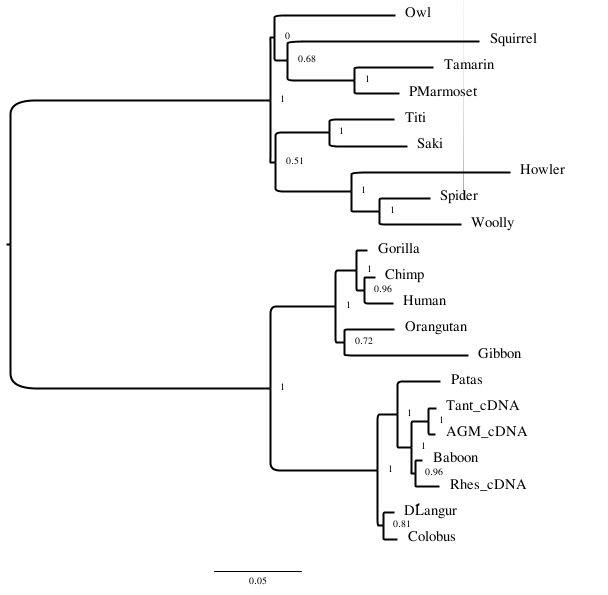

- Veamos los parámetros relevantes

```
cat primates_21_AA.phy_phyml_stats.txt
```

```
...truncado
. Sequence filename:            primates_21_AA.phy
. Data set:                 #1
. Initial tree:             BioNJ
. Model of amino acids substitution:    JTT
. Number of taxa:           21
. Log-likelihood:           -4775.99427
. Unconstrained log-likelihood:     -2434.66382
. Composite log-likelihood:         -30488.21256
. Parsimony:                560
. Tree size:                1.29999
. Discrete gamma model:         Yes
  - Number of classes:          4
  - Gamma shape parameter:      0.718
  - Relative rate in class 1:       0.07800 [freq=0.250000]
  - Relative rate in class 2:       0.37181 [freq=0.250000]
  - Relative rate in class 3:       0.93129 [freq=0.250000]
  - Relative rate in class 4:       2.61890 [freq=0.250000]

. Run ID:               none
. Random seed:              1659906799
. Subtree patterns aliasing:        no
. Version:              3.3.3:3.3.20190909-1
. Time used:                0h0m14s (14 seconds)
...truncado
```

# 5 Selección automatizada de modelos de DNA y proteína por $BIC$ con *phyml_DNAmodelFinder.sh* y *phyml_protModelFinder.sh*

Si bien en el ejemplo anterior hemos intentado optimizar nuestro análisis corriendo un bucle for y guardando los valores de $lnL$ para cada modelo en el hash $model\_scores$, este trabajo sigue siendo tedioso, con mucha intervención manual, lo cual, además de lento, nos expone a cometer errores.

Los pasos seguidos son fácilmente automatizables mediante un $script$ en $Bash$ u otro lenguaje. Además del $bucle\ for$ y el $hash$, vamos a poder optimizar el proceso si escribimos $funciones$ que encapsulen el trabajo de las diferentes operaciones que tenemos que hacer de manera repetida. Como discutimos en el tema de funciones, éstas son fundamentales para modularizar el código en unidades lógicas autocontenidas, lo cual es esencial para escribir programas complejos y poderlos mantener y desarrollar con facilidad.

Vamos a cerrar este tutorial corriendo los scripts `phyml_protModelFinder.sh` y `phyml_DNAmodelFinder.sh`, que pueden descargar a su directorio `~/bin` desde el [repositorio GitHub de los TIB](https://github.com/vinuesa/TIB-filoinfo), usando $wget$:

```
# si no existe el directorio ~/bin, entonces generalo
[ ! -d ~/bin ] && mkdir ~/bin

# cámbiate al directorio ~/bin y llama a wget para decargar los scripts
cd ~/bin
wget -c https://raw.githubusercontent.com/vinuesa/TIB-filoinfo/master/phyml_protModelFinder.sh
wget -c https://raw.githubusercontent.com/vinuesa/TIB-filoinfo/master/phyml_DNAmodelFinder.sh

# haz ejecutables los scripts de shell (*.sh) descargados
chmod 755 *sh

# regresa al directorio previo (de trabajo)
cd -
```

Estos $scripts$, además de hacer las llamadas a $phyml$, evalúan los resultados haciendo uso de los criterios de información de Akaike ($AIC$) y bayesiano ($BIC$).

Veremos que el $AIC$ usa un criterio más laxo que el $BIC$, tendiendo a seleccionar modelos más complejos que el segundo.

Te invito a que explores en detalle el código de ambos.

**NOTA**: Los scripts *phyml_protModelFinder.sh*, y en particular *phyml_DNAmodelFinder.sh*, hacen uso de sintaxis moderna de *Bash*, por lo que requiren una versión reciente (>= 5.1.0) del intérprete de comandos $bash$ para poder hacer uso de toda la funcionalidad que ofrecen.

Puedes ver la versión de $bash$ de tu sistema con el siguiente comando `bash –version`.

## 5.1 Ejemplo de invocación del script *phyml_protModelFinder.sh*

Vamos a correr el $phyml\_protModelFinder.sh$ para automatizar la selección de modelos para proteínas y la inferencia de la filogenia correspondiente.

```
# despliegue de la ayuda
phyml_protModelFinder.sh
```

```
 USAGE for phyml_protModelFinder.sh v2.2.3_2025-08-06:
 phyml_protModelFinder.sh -i  -m  [-b <(-)int>] [ -h ] [-r ] [-s ] [ -v ]

 REQUIRED:
  -i  input alignment in PHYLIP format
  -m  model set to evaluate by BIC
       1 -> nuclear genes (AB BLOSUM62 DAYHOFF DCMut JTT LG VT WAG)
       2 -> organellar genes (CpREV MTMAM MtREV MtArt)
       3 -> nuclear and organellar (1 + 2)
       4 -> retroviral genes (HIVw HIVb RtREV)
       5 -> nuclear + retroviral genes (1 + 4)
       6 -> all (1+2+3+4+5)
       7 -> test (JTT LG)

 OPTIONAL
  -h  print help (this message)
  -b
      int > 0: int is the number of bootstrap replicates.
       0: neither approximate likelihood ratio test nor bootstrap values are computed.
      -1: approximate likelihood ratio test returning aLRT statistics.
      -2: approximate likelihood ratio test returning Chi2-based parametric branch supports.
      -4: SH-like branch supports alone.
      -5: (default) approximate Bayes branch supports.
  -s  Search (branch-swapping) method; default:BEST
  -r  number of random start trees to use for sequential searches; default rand_starts:1
  -v  print version

 EXAMPLES:
   phyml_protModelFinder.sh -i my_PHYLIP_alignment.phy -m 1 -b -4 -r 10

 NOTES:
  1. Assumes protein input sequences are ALIGNED and in (relaxed) PHYLIP format

 AIM: phyml_protModelFinder.sh v2.2.3_2025-08-06 will evaluate the fit of the the seleced model set,
       combined or not with +G and/or +f, computing AICi, BICi, deltaBIC, BICw
    and inferring the ML tree under the BIC-selected model and the
    use-selected search method (N|S|B) and number os start trees.

 PROCEDURE
   - Models are fitted using a fixed NJ-LG tree, optimizing branch lenghts and rates
    to calculate their AICi, BICi, delta_BIC and BICw
   - The best model is selected by BIC
   - SPR searches can be launched starting from multiple random trees
   - Default single seed tree searches use a BioNJ with BEST moves


 SOURCE: the latest version can be fetched from https://github.com/vinuesa/TIB-filoinfo

 LICENSE: GPL v3.0.
    See https://github.com/vinuesa/get_phylomarkers/blob/master/LICENSE
```

Vemos que necesitamos pasarle dos parámetros: el archivo phylip con las secuencias alineadas y elejir un set de matrices a evaluar.

Hay un tercer parámetro $<int>$ opcional, que nos permite indicarle al programa que queremos hacer la búsqueda final de árboles a partir de $n$ árboles de semilla de adición secuencial aleatorizada, bajo el mejor modelo seleccionado.

```
phyml_protModelFinder.sh -i primates_21_AA.phy -m 5
```

Abajo vemos el STDOUT del $script$.

```
function compute_AA_freq_in_phylip()
{
  local phylip
  phylip=$1

  awk '
  BEGIN{print "idx\tAA\tobs_freq"}
  {
    # ignore first row and column
    if( NR > 1 && NF > 1){
       # remove empty spaces
       gsub(/[ ]+/," ")
       l=length($0)

       for(i=1; i<=l; i++){
          c = substr($0, i, 1)

      # count only standard amino acids
      if (c ~ /[ARNDCQEGHILKMFPSTWYV]/){
              ccounts[c]++
              letters++
          }
       }
    }
  }
  # print relative frequency of each residue
  END {
     for (c in ccounts){
        aa++
        printf "%i\t%s\t%.4f\n", aa, c, (ccounts[c] / letters )
     }
  }' "$phylip"
}
```

Puedes copiar la función a la terminal y llamarla desde la línea de comandos:

```
compute_AA_freq_in_phylip primtates_21_AA.phy
```

- Seguidamente construye un **árbol NJ-LG** que será usado, como en los ejemplos anteriores, para fijar la topología en las llamadas a $phyml$ para optimizar parámetros del modelo y calcular el ajuste de $lnL$
- Se entra al **bucle principal del $script$**, que hace llamadas a $phyml$ con cada uno de los modelos a evaluar, llenando diversos hashes con los resultados para su despliegue y posterior análisis estadístico.
- Una vez estimados los parámetros y calculados los puntajes de verosimilitud correspondientes, se calculan los $AIC_i$, $AIC_c$, $BIC_i$, $\Delta_{BIC}$, $BIC_w$ y $BIC_{cumW}$ asociados a cada modelo, haciendo llamadas a funciones, se guardan los resultados en un $hash$ y se imprime finalmente la tabla de resultados, ordenada por valores crecientes de BIC.
- Por último se usa el mejor modelo (seleccionado por $BIC$), para estimar la filogenia, bien sea a partir de un árbol semilla $BioNJ$ con rearreglos tipo $BEST$ (por defecto). Si se le pasa al script un íntegro como tercer parámetro, generará ese número de **árboles de semilla de adición secuencial aleatorizada**, a partir de los cuales hace búsquedas con rearreglos de tipo $SPR$.

```
$ phyml_protModelFinder.sh primates_21_AA.phy 5
=========================================================================================
# Bash version 5.1 OK
# phyml_protModelFinder.sh v0.9_2023-11-17 running on alisio. Run started on: 2023-11-19 at 18:35:44
# running with phyml v.3.3_2023
/home/vinuesa/anaconda3/bin/mpirun
/usr/bin/phyml-mpi
/usr/bin/awk
/home/vinuesa/anaconda3/bin/bc
/usr/bin/sed
/home/vinuesa/anaconda3/bin/perl
/usr/local/bin/phyml

# Run check_dependencies() ... looks good: all required binaries are in place.

# infile:primates_21_AA.phy; model_set:5; mpi_OK:1; seed trees: 1
=========================================================================================

18:35:44  # 1. Computing sequence stats for primates_21_AA.phy:
- number of sequences: 21
- number of sites: 500
- number of branches: 39
- observed amino acid frequencies:
idx AA  obs_freq
1   N   0.0423
2   A   0.0442
3   P   0.0439
4   C   0.0396
5   D   0.0399
6   Q   0.0656
7   R   0.0545
8   E   0.0939
9   F   0.0381
10  S   0.0713
11  T   0.0424
12  G   0.0414
13  H   0.0287
14  V   0.0763
15  I   0.0491
16  W   0.0135
```

[output cut: 113 more lines]

```
--------------------------------------------------------------------------------------------------

Elapsed time: 0 days, 00 hr, 00 min, 33 sec
Done!
  ========================================================================================
  If you use phyml_protModelFinder.sh v.0.9_2023-11-17 for your research,
  I would appreciate that you:

  1. Cite the code in your work as:
  Pablo Vinuesa. phyml_protModelFinder.sh v.0.9_2023-11-17
       https://github.com/vinuesa/TIB-filoinfo/blob/master/phyml_protModelFinder.sh

  2. Give it a like on the https://github.com/vinuesa/TIB-filoinfo/ repo

  Thanks!
```

Podemos desplegar el árbol directamente en la terminal usando herramientas del paquete [$newick\_utilities$](https://github.com/tjunier/newick_utils).

```
nw_display -w 120 <(nw_reroot primates_21_AA.phy_HIVb+G_BESTmoves_phyml_tree.txt)
```

```
                                                                            +-+ Gorilla
                                                                        +---+ 0.999542Human
                                                                        |   +-+ 0.988925
                                                          +-------------+ 0.999985Chimp
                                                          |             |
                                                          |             |+-------------------------+ Gibbon
                                                          |             ++ 0.731672
                                                          |              +----------+ Orangutan
 +--------------------------------------------------------+ 1.000000                 +--------+ Patas
 |                                                        |                          |
 |                                                        |                      +---+ 1.000000AGM cDNA
 |                                                        |                      |   |  +--+ 1.000000
 |                                                        |                      |   |  |  +-+ Tant cDNA
 |                                                        |                      |   +--+ 0.999995
 |                                                        |                      |      |-+ Baboon
 |                                                        +----------------------+ 1.000000.977694
 |                                                                               |      +----+ Rhes cDNA
 |                                                                               |
=|                                                                               |+--+ Colobus
 |                                                                               ++ 0.776704
 |                                                                                +-+ DLangur
 |                                                          +-----------------------+ Owl
 |                                                          |
 |                                                        +-+ 0.550063    +---------------+ Tamarin
 |                                                        | +-------------+ 1.000000
 |                                                        |               +---------+ PMarmoset
 |                                                        |
 +--------------------------------------------------------+ 0.419386----------------------------------+ Squirrel
                                                          |  |
                                                          |+-+ 0.633907+-------------+ Titi
                                                          || +---------+ 1.000000
                                                          ++ 1.000000  +----------------+ Saki
                                                           |               +---------------------------------+ Howler
                                                           |               |
                                                           +---------------+ 0.999170-------------+ Woolly
                                                                           +-----+
                                                                                 +----------+ Spider

 |----------------|-----------------|----------------|----------------|-----------------|----------------|----
 0             0.05               0.1             0.15              0.2              0.25              0.3
 substitutions/site
```

**Figura 6.** Filogenia de máxima verosimilitud bajo el modelo $HIVb+G$ seleccionado automáticamente por $phyml\_protModelFinder.sh$ en base a valores de $BIC$, y desplegada directamente en la terminal con herramientas del paquete [$newick\_utilities$](https://github.com/tjunier/newick_utils)

Noten cómo llamamos a $nw\_reroot$ para hacer un **enraizamiento en el punto medio**, pasando el resultado a $nw\_display$, haciendo uso de lo que se conoce como **sustitución de proceso** `comando2 <(comando1)`, que pasa la salida de *comando1* como si fuera un archivo que lee *comando2*.

Gracias a la **sustitución de proceso** evitamos tener que escribir un archivo intermedio con la filogenia enraizada, para ser desplegada por $nw\_display$

Les muestro abajo un ejemplo más avanzado del uso de **sustitución de proceso** que hacen los scripts $phyml\_DNAmodelFinder$ y $phyml\_protModelFinder$ para añadir las columnas $\Delta_{BIC}$, $BIC_w$ y $BIC_{cumW}$ a la tabla de resultados.

```
# 6.4 paste the BIC_deltas_a & BICw_a values as a new column to
#      "${infile}"_sorted_model_set_"${model_set}"_fits.tsv
paste "${infile}"_sorted_model_set_"${model_set}"_fits.tsv \
  <(for i in "${BIC_deltas_a[@]}"; do echo "$i"; done) \
  <(for i in "${BICw_a[@]}"; do echo "$i"; done) \
  <(for i in "${BICcumW_a[@]}"; do echo "$i"; done) > t

[[ -s t ]] && mv t "${infile}"_sorted_model_set_"${model_set}"_fits.tsv
```

### 5.1.1 El criterio bayesiano de información ($BIC$)

Noten que el mejor modelo seleccionado por $BIC$ caso es $HIVb+G$, mientras que $AIC$ selecciona $HIVw+f+G$. Es más, vemos que $HIVw+f+G$ tiene un $\Delta_{BIC}$ > 6, por lo que es un modelo claramente peor que el $HIVb+G$. Es tan grande la distancia $\Delta_{BIC}$ entre ambos modelos, que $HIVw+f+G$ tiene un $BIC_w\ =\ 0.03$.

¿A qué se debe esta disparidad entre $AIC$ y $BIC$? El criterio de información de Akaike ($AIC$) es sabido que tiende a favorecer modelos con más parámetros, y con frecuencia selecciona modelos sobreparametrizados.

Por ello los $scripts$ $phyml\_protModelFinder.sh$ y $phyml\_DNAmodelFinder.sh$ usan el $BIC$ para la selección de modelos.

El $BIC$ para un modelo se define de la siguiente manera:

**$BIC_i=-2lnL_i + K_i * log(N)$**

donde:

- $lnL_i=log-Likelihood\ del\ modelo\ i$
- $K=número\ de\ parámetros\ libres\ del\ modelo\ i$
- $N=número\ de\ sitios\ del\ alineamiento$,

Noten que $K_i$ debería considerar además el número de ramas libres a estimar ($2n-3$; $n = num\_secuencias$), por lo que:

- $K_i=número\ de\ parámetros\ libres\ del\ modelo\ i + (2n - 3)$

Al igual que con los $AIC$, el modelo con menor $BIC$ es el preferido, el cual equivale al modelo de máxima probabilidad posterior.

Dado que para muchos alineamientos $log(n) > 2$, el $BIC$ suele seleccionar modelos con menos parámetros que $AIC$.

Con $BIC$ podemos comparar todos los modelos en competición, independientemente de si están o no anidados.

### 5.1.2 Tarea: selección de modelos con BIC

```
1. Calcula manualmente los valores de $BICi$, $BIC_{MIN}$ y $\Delta_{BIC}$ $para los modelo $HIVb+G$ y $HIVb+f+G$
del alineamiento de primates_21_AA.phy, usando la fórmula mostrada en la sección de $BIC$ y los datos que imprime
$phyml\_protModelFinder.sh$ al inicio de su salida.
2. Vuelve a correr el script, pero evaluando todos los modelos. $phyml\_protModelFinder.sh$ ¿Hay alguna diferencia? Comenta el resultado.
3. Si no lo has hecho aún, repite el ejercicio de selección de modelos paramétricos (de DNA) con las secuencias *primates.phy*, usando $BIC$.
```

## 5.2 Selección “inteligente” de subconjuntos de modelos de sustitución para DNA con *phyml_DNAmodelFinder.sh*

El $script$ *phyml_DNAmodelFinder.sh* tiene una estructura similar a *phyml_protModelFinder.sh*, pero es algo más complejo, ya que el usuario puede pedirle que evalúe el **conjunto de modelos estándar (JC69, K80, F81, HKY85, TN93 y GTR)** más un conjunto amplio de modelos transicionales (TIM*) y transversionales (TVM*), con 3, 4 y 5 clases de tasas, los cuales son elegidos después de comprobar si existe o no un sesgo transicional significativo.

**NOTA:** $phyml\_DNAmodelFinder.sh$ hace uso de idiomas más avanzados y recientes del lenguaje *Bash* que $phyml\_protModelFinder.sh$, ya que además de `arreglos` y `hashes`, usa `referencias` a los mismos para pasarlos a funciones. Por tanto la funcionalidad completa del script sólo está disponible si usas una versión de $bash >= 5.1$.

Veamos la ayuda de $phyml\_DNAmodelFinder.sh$:

```
 phyml_DNAmodelFinder.sh -i  -m  [-b <(-)int>] [ -h ] [-r ] [-s ] [ -v ]

 REQUIRED:
  -i  input alignment in PHYLIP format
  -m  model set to evaluate by BIC
       1 -> standard models (JC69 K80 F81 HKY85 TN93 GTR)
       2 -> standard + 64 extended_ef_models, OR
            standard + 62 extended_uf_models

            NOTE: phyml_DNAmodelFinder.sh automatically chooses the proper extended set (ef|uf) to evaluate,
                 based on delta_BIC evaluation of compositional bias (JC69 vs. F81)
        3 -> minimal test set (JC69 F81 HKY85 TN93)

 OPTIONAL
  -h  print help (this message)
  -b
      int > 0: int is the number of bootstrap replicates.
       0: neither approximate likelihood ratio test nor bootstrap values are computed.
      -1: approximate likelihood ratio test returning aLRT statistics.
      -2: approximate likelihood ratio test returning Chi2-based parametric branch supports.
      -4: SH-like branch supports alone.
      -5: (default) approximate Bayes branch supports.
  -s  search (branch-swapping) method; default:BEST
  -r  number of random start trees to use for sequential searches; default rand_starts:1
  -v  print version

 EXAMPLE:
   phyml_DNAmodelFinder.sh -i my_PHYLIP_alignment.phy -m 2 -b -4 -r 10 -s NNI

 NOTES: 1. Assumes DNA input sequences are ALIGNED and in (relaxed) PHYLIP format

 AIM:  phyml_DNAmodelFinder.sh v2.1.1_2024-12-13 will evaluate the fit of the selected model set,
    combined or not with +G and/or +f, computing AICi, BICi, deltaBIC and BICw,
          inferring the ML tree under the BIC-selected model

 PROCEDURE
  - Models are fitted using a fixed NJ-JC tree, optimizing branch lenghts and rates
       to calculate their AICi, BICi, delta_BIC and BICw
  - Only relevant models among the extended set are evaluated, based on delta_BIC
      comparisons between JC69-F81, to decide if ef|uf models should be evaluated,
      and comparisons between KHY85-TN93 to determine if models with two Ti rates should
      be evaluated
  - pInv is automatically excluded in the extended model set,
      if the delta_BICi_HKY+G is =< 2 when compared with the BIC_HKY+G+I
  - The best model is selected by BIC
  - SPR searches can be launched starting from multiple random trees
  - Default single seed tree searches use a BioNJ with BEST moves

 SOURCE: the latest version of the program is available on GitHub:
     https://github.com/vinuesa/TIB-filoinfo

 LICENSE: GPL v3.0. See https://github.com/vinuesa/get_phylomarkers/blob/master/LICENSE

 CITATION: Vinuesa P. (2023). Efficient two-step selection of DNA models with phyml_DNAmodelFinder.
             https://github.com/vinuesa/TIB-filoinfo
```

Al elegir el *set 2* de modelos, en vez de evaluar a todos los modelos estándar+TIM+TVM, *phyml_DNAmodelFinder.sh* hace unas evaluaciones de valores de $\Delta_{BIC}$ entre los siguientes pares de modelos:

```
- *JC69 vs. F81* para determinar si existe un **sesgo composicional** significativo
- *HKY85 vs. TN93* para evaluar si existe un **sesgo transicional entre purinas y pirimidinas** significativo
- *HKY85+G vs. HKY85+I+G* para calcular si amerita o no incluir una **proporción de sitios invariantes**
```

En función de estos análisis, efectuados sobre los modelos del conjunto estándar, el $script$ decide qué conjuntos de modelos adicionales evaluar:

- TIM con con uf|ef
- TVM con con uf|ef
- añadir o no +I

### 5.2.1 Ejemplo de corrida *phyml_DNAmodelFinder.sh* en modo de selección de set extendido de modelos

Al igual que *phyml_protModelFinder.sh*, *phyml_DNAmodelFinder.sh* primero verifica:

- el ambiente en el que corre (verión de $Bash$ y dependencias)
- que las secuencias están en formato $phylip$
- calcula unas estadísticas descriptivas de las secuencias

```
phyml_DNAmodelFinder.sh -i primates.phy -m 2
```

```
# invocation: phyml_DNAmodelFinder.sh  -i primates.phy -m 2
# checking PhyML version
=========================================================================================
# Bash version 5.2 OK
# running with phyml v.3.3_2023
/usr/bin/awk
/usr/bin/bc
/usr/bin/sed
/usr/bin/perl
/usr/local/bin/phyml

# Run check_dependencies() ... looks good: all required binaries are in place.

# phyml_DNAmodelFinder.sh v2.1.1_2024-12-13 running on alisio. Run started on: 2025-08-06 at 20:30:26
# working directory: /home/vinuesa/Cursos/TIB/TIB24/sesion6_maxima_verosimilitud/data
# infile:primates.phy; model_set:2 => extended_models; seed trees: 1; delta_BIC_cutoff=2; branch_support_type=-5
========================================================================================

18:54:14  # 1. Computing sequence stats for primates.phy:
- number of sequences: 12
- number of sites: 898
- number of branches: 21
- observed nucleotide frequencies:
idx NT  obs_freq
1   A   0.3241
2   C   0.3040
3   T   0.2664
4   G   0.1056
--------------------------------------------------------------------------------
```

Queda claro del análisis de frecuencias empríricas que existe un sesgo composicional importante en los datos, por lo que *phyml_DNAmodelFinder.sh* debería favorecer modelos que lo consideren.

En los siguientes pasos:

1. Calcula un árbol NJ-JC que servirá de topología de referencia
2. Ajusta los modelos de base, haciendo uso del árbol NJ-JC
3. Calucula los $AIC$, $AICc$ y $BIC$ para estos modelos de base e imprime a pantalla los valores de $BIC_i$ para los modelos arriba enlistados, en base a los cuales toma la decisión de qué tipo de modelos adicionales evaluar.

```
18:54:14 1. Computing NJ-JC tree for input file primates.phy with 12 sequences
--------------------------------------------------------------------------------
2.1. running in a for loop to combine all base models in model_set 2=>extended_models,
     with (or without) +G and or +I, and compute the model lnL, after optimizing branch lengths and rates
18:54:14 # running: phyml -i primates.phy -d nt -m JC69 -f m -u primates.phy_JC-NJ.nwk -c 1 -v 0 -o lr
JC_BICi: 12991.20847
18:54:15 # running: phyml -i primates.phy -d nt -m JC69 -f m -c 4 -a e -u primates.phy_JC-NJ.nwk -o lr
18:54:15 # running: phyml -i primates.phy -d nt -m JC69 -f m -v e -c 1 -u primates.phy_JC-NJ.nwk -o lr
18:54:15 # running: phyml -i primates.phy -d nt -m JC69 -f m -u primates.phy_JC-NJ.nwk -v e -a e -o lr
18:54:15 # running: phyml -i primates.phy -d nt -m K80 -f m -u primates.phy_JC-NJ.nwk -c 1 -v 0 -o lr
18:54:15 # running: phyml -i primates.phy -d nt -m K80 -f m -c 4 -a e -u primates.phy_JC-NJ.nwk -o lr
18:54:15 # running: phyml -i primates.phy -d nt -m K80 -f m -v e -c 1 -u primates.phy_JC-NJ.nwk -o lr
18:54:15 # running: phyml -i primates.phy -d nt -m K80 -f m -u primates.phy_JC-NJ.nwk -v e -a e -o lr
18:54:16 # running: phyml -i primates.phy -d nt -m F81 -f m -u primates.phy_JC-NJ.nwk -c 1 -v 0 -o lr
F81_BICi: 12733.19534
18:54:16 # running: phyml -i primates.phy -d nt -m F81 -f m -c 4 -a e -u primates.phy_JC-NJ.nwk -o lr
18:54:16 # running: phyml -i primates.phy -d nt -m F81 -f m -v e -c 1 -u primates.phy_JC-NJ.nwk -o lr
18:54:16 # running: phyml -i primates.phy -d nt -m F81 -f m -u primates.phy_JC-NJ.nwk -v e -a e -o lr
18:54:16 # running: phyml -i primates.phy -d nt -m HKY85 -f m -u primates.phy_JC-NJ.nwk -c 1 -v 0 -o lr
HKY85_BICi: 12133.44475
18:54:16 # running: phyml -i primates.phy -d nt -m HKY85 -f m -c 4 -a e -u primates.phy_JC-NJ.nwk -o lr
HKY85+G_BICi: 11475.87798
18:54:17 # running: phyml -i primates.phy -d nt -m HKY85 -f m -v e -c 1 -u primates.phy_JC-NJ.nwk -o lr
18:54:17 # running: phyml -i primates.phy -d nt -m HKY85 -f m -u primates.phy_JC-NJ.nwk -v e -a e -o lr
HKY85+I+G_BICi: 11477.88060
18:54:18 # running: phyml -i primates.phy -d nt -m TN93 -f m -u primates.phy_JC-NJ.nwk -c 1 -v 0 -o lr
TN93_BICi: 12134.51460
18:54:18 # running: phyml -i primates.phy -d nt -m TN93 -f m -c 4 -a e -u primates.phy_JC-NJ.nwk -o lr
18:54:18 # running: phyml -i primates.phy -d nt -m TN93 -f m -v e -c 1 -u primates.phy_JC-NJ.nwk -o lr
18:54:18 # running: phyml -i primates.phy -d nt -m TN93 -f m -u primates.phy_JC-NJ.nwk -v e -a e -o lr
--------------------------------------------------------------------------------
18:54:20 # Starting evaluation and automatic selection of extended model set
# setting compositional_heterogeneity flag to: 1
--------------------------------------------------------------------------------
18:54:20 # ... evaluation and automatic selection of extended model set
# setting transitional_heterogeneity flag to: 0
--------------------------------------------------------------------------------
18:54:20 # ... evaluation and automatic selection of extended model set
# setting use_pInv flag to: 0
# will evaluate models with unequal frequencies
--------------------------------------------------------------------------------
```

Como ven arriba, el $script$ detecta:

1. un sesgo composicional significativo, `compositional_heterogeneity_flag=1`
2. No considera significativa la diferencia de tasas de transiciones entre purinas y pirimidinas `transitional_heterogeneity_flag=0`
3. Tampoco considera que el parámetro $pInv$ incremente significativamente el ajuste, por lo que `use_pInv_flag=0`

En el siguiente ciclo, el programa evaluará sólo modelos $TVM*$ del set extendido, con estima empírica de la frecuencia de las bases, sin $pInv$

```
18:54:20 2.2. running a loop to combine the extended models in model_set 2=>extended_models,
      with (or not) +G and or +I, and compute the model lnL, after optimizing branch lengths and rates
skipping TN|TIM|SYM matrix 012230
skipping TN|TIM|SYM matrix 010023
skipping TN|TIM|SYM matrix 010232
skipping TN|TIM|SYM matrix 012232
skipping TN|TIM|SYM matrix 012332
skipping TN|TIM|SYM matrix 012342
skipping TN|TIM|SYM matrix 012343
skipping TN|TIM|SYM matrix 012340
skipping TN|TIM|SYM matrix 010021
skipping TN|TIM|SYM matrix 010022
skipping TN|TIM|SYM matrix 010120
skipping TN|TIM|SYM matrix 011123
skipping TN|TIM|SYM matrix 012223
skipping TN|TIM|SYM matrix 012222
skipping TN|TIM|SYM matrix 000120
skipping TN|TIM|SYM matrix 000121
skipping TN|TIM|SYM matrix 001021
skipping TN|TIM|SYM matrix 012234
skipping TN|TIM|SYM matrix 010231
skipping TN|TIM|SYM matrix 011020
skipping TN|TIM|SYM matrix 011230
skipping TN|TIM|SYM matrix 012130
skipping TN|TIM|SYM matrix 010121
skipping TN|TIM|SYM matrix 010122
skipping TN|TIM|SYM matrix 010123
skipping TN|TIM|SYM matrix 001020
skipping TN|TIM|SYM matrix 000123
skipping TN|TIM|SYM matrix 010203
skipping TN|TIM|SYM matrix 010223
skipping TN|TIM|SYM matrix 010230
skipping TN|TIM|SYM matrix 012032
skipping TN|TIM|SYM matrix 010233
skipping TN|TIM|SYM matrix 001234
skipping TN|TIM|SYM matrix 010234
skipping TN|TIM|SYM matrix 011234
skipping TN|TIM|SYM matrix 012134
skipping TN|TIM|SYM matrix 012304
skipping TN|TIM|SYM matrix 012324
```

[output cut: 52 more lines]

```
18:54:26 # running: phyml -i primates.phy -d nt -m 000101  -f m  -c 4 -a e -u primates.phy_JC-NJ.nwk -o lr
skipping  000101+I and 000101+I+G
18:54:26 # running: phyml -i primates.phy -d nt -m 010110  -f m  -u primates.phy_JC-NJ.nwk -c 1 -v 0 -o lr
18:54:27 # running: phyml -i primates.phy -d nt -m 010110  -f m  -c 4 -a e -u primates.phy_JC-NJ.nwk -o lr
skipping  010110+I and 010110+I+G
18:54:27 # running: phyml -i primates.phy -d nt -m 000102  -f m  -u primates.phy_JC-NJ.nwk -c 1 -v 0 -o lr
18:54:27 # running: phyml -i primates.phy -d nt -m 000102  -f m  -c 4 -a e -u primates.phy_JC-NJ.nwk -o lr
skipping  000102+I and 000102+I+G
18:54:27 # running: phyml -i primates.phy -d nt -m 010112  -f m  -u primates.phy_JC-NJ.nwk -c 1 -v 0 -o lr
18:54:27 # running: phyml -i primates.phy -d nt -m 010112  -f m  -c 4 -a e -u primates.phy_JC-NJ.nwk -o lr
skipping  010112+I and 010112+I+G
18:54:27 # running: phyml -i primates.phy -d nt -m 010211  -f m  -u primates.phy_JC-NJ.nwk -c 1 -v 0 -o lr
18:54:27 # running: phyml -i primates.phy -d nt -m 010211  -f m  -c 4 -a e -u primates.phy_JC-NJ.nwk -o lr
skipping  010211+I and 010211+I+G
--------------------------------------------------------------------------------
```

Como puede verse en la salida del programa arriba mostrada, ajusta modelos $TVM*+G$, estimando frecuencia de bases $-f\ e$, e ignorando los modelos $Tn|TIM|SYM$, con dos tasas de transiciones.

Una vez evaluados los dos conjuntos de modelos (base + selección de modelos extendidos), calcula diversos estadísticos de cirterios de información, tanto de Akaike como bayesiano, ordenando los resultados por valores crecientes de $BIC$, e imprimiendo también los valores de $\Delta_{BIC}$, $BIC_{w_i}$ y $BICcumW$.

```
18:54:28 # writing primates.phy_sorted_model_set_2_fits.tsv, sorted by BIC; extmodels+F true
--------------------------------------------------------------------------------
model       K   sites/K   lnL          AIC          AICc         BIC          deltaBIC    BICw  BICcumW
HKY85+G     26  34.53000  -5711.93899  11475.87798  11477.48992  11600.68240  0           0.85  0.85
TN93+G      27  33.25000  -5710.55176  11475.10352  11476.84145  11604.70811  4.02571     0.11  0.97
HKY85+I+G   27  33.25000  -5711.94030  11477.88060  11479.61853  11607.48519  6.80279     0.03  1.00
TN93+I+G    28  32.07000  -5710.55229  11477.10458  11478.97339  11611.50934  10.82694    0.00  1.00
010212+G+F  27  33.25000  -5721.62318  11497.24636  11498.98429  11626.85095  26.16855    0.00  1.00
012212+G+F  27  33.25000  -5722.51008  11499.02016  11500.75809  11628.62475  27.94235    0.00  1.00
010012+G+F  27  33.25000  -5722.63081  11499.26162  11500.99955  11628.86621  28.18381    0.00  1.00
012313+G+F  28  32.07000  -5719.92282  11495.84564  11497.71445  11630.25040  29.56800    0.00  1.00
012213+G+F  28  32.07000  -5720.26837  11496.53674  11498.40555  11630.94150  30.25910    0.00  1.00
010213+G+F  28  32.07000  -5720.86864  11497.73728  11499.60609  11632.14204  31.45964    0.00  1.00
012013+G+F  28  32.07000  -5722.34471  11500.68942  11502.55823  11635.09418  34.41178    0.00  1.00
010210+G+F  27  33.25000  -5725.84777  11505.69554  11507.43347  11635.30013  34.61773    0.00  1.00
012012+G+F  27  33.25000  -5726.25000  11506.50000  11508.23793  11636.10459  35.42219    0.00  1.00
012314+G+F  29  30.96000  -5719.45652  11496.91304  11498.91765  11636.11797  35.43557    0.00  1.00
012210+G+F  27  33.25000  -5726.65816  11507.31632  11509.05425  11636.92091  36.23851    0.00  1.00
012310+G+F  28  32.07000  -5725.20152  11506.40304  11508.27185  11640.80780  40.12540    0.00  1.00
HKY85+I     26  34.53000  -5768.00399  11588.00798  11589.61992  11712.81240  112.13000   0.00  1.00
TN93+I      27  33.25000  -5766.10222  11586.20444  11587.94237  11715.80903  115.12663   0.00  1.00
010211+G+F  27  33.25000  -5804.50691  11663.01382  11664.75175  11792.61841  191.93601   0.00  1.00
010011+G+F  26  34.53000  -5810.83201  11673.66402  11675.27596  11798.46844  197.78604   0.00  1.00
010112+G+F  27  33.25000  -5816.57851  11687.15702  11688.89495  11816.76161  216.07921   0.00  1.00
010110+G+F  26  34.53000  -5823.31701  11698.63402  11700.24596  11823.43844  222.75604   0.00  1.00
001101+G+F  26  34.53000  -5913.85413  11879.70826  11881.32020  12004.51268  403.83028   0.00  1.00
011010+G+F  26  34.53000  -5917.56175  11887.12350  11888.73544  12011.92792  411.24552   0.00  1.00
K80+G       23  39.04000  -5950.87340  11947.74680  11949.00996  12058.15071  457.46831   0.00  1.00
K80+I+G     24  37.41000  -5950.57605  11949.15210  11950.52667  12064.35618  463.67378   0.00  1.00
012313+F    27  33.25000  -5950.31559  11954.63118  11956.36911  12084.23577  483.55337   0.00  1.00
012213+F    27  33.25000  -5952.11058  11958.22116  11959.95909  12087.82575  487.14335   0.00  1.00
012314+F    28  32.07000  -5949.09947  11954.19894  11956.06775  12088.60370  487.92130   0.00  1.00
010212+F    26  34.53000  -5959.18463  11970.36926  11971.98120  12095.17368  494.49128   0.00  1.00
012212+F    26  34.53000  -5959.65943  11971.31886  11972.93080  12096.12328  495.44088   0.00  1.00
010213+F    27  33.25000  -5957.06064  11968.12128  11969.85921  12097.72587  497.04347   0.00  1.00
K80+I       23  39.04000  -5974.90514  11995.81028  11997.07344  12106.21419  505.53179   0.00  1.00
010012+F    26  34.53000  -5964.74421  11981.48842  11983.10036  12106.29284  505.61044   0.00  1.00
012013+F    27  33.25000  -5962.12925  11978.25850  11979.99643  12107.86309  507.18069   0.00  1.00
012012+F    26  34.53000  -5974.64960  12001.29920  12002.91114  12126.10362  525.42122   0.00  1.00
010210+F    26  34.53000  -5976.57458  12005.14916  12006.76110  12129.95358  529.27118   0.00  1.00
```

[output cut: 13 more lines]

```
F81+I+G     26  34.53000  -6103.95758  12259.91516  12261.52710  12384.71958  784.03718   0.00  1.00
F81+I       25  35.92000  -6117.43632  12284.87264  12286.36347  12404.87689  804.19449   0.00  1.00
K80         22  40.81000  -6142.42909  12328.85818  12330.01475  12434.46192  833.77952   0.00  1.00
011010+F    25  35.92000  -6167.29688  12384.59376  12386.08459  12504.59801  903.91561   0.00  1.00
000101+F    25  35.92000  -6198.63537  12447.27074  12448.76157  12567.27499  966.59259   0.00  1.00
000102+F    26  34.53000  -6197.84929  12447.69858  12449.31052  12572.50300  971.82060   0.00  1.00
000100+F    25  35.92000  -6259.08395  12568.16790  12569.65873  12688.17215  1087.48975  0.00  1.00
JC69+G      22  40.81000  -6272.46906  12588.93812  12590.09469  12694.54186  1093.85946  0.00  1.00
JC69+I+G    23  39.04000  -6269.14954  12584.29908  12585.56224  12694.70299  1094.02059  0.00  1.00
JC69+I      22  40.81000  -6277.78094  12599.56188  12600.71845  12705.16562  1104.48322  0.00  1.00
F81         24  37.41000  -6284.99563  12617.99126  12619.36583  12733.19534  1132.51294  0.00  1.00
JC69        21  42.76000  -6424.20245  12890.40490  12891.45969  12991.20847  1390.52607  0.00  1.00
--------------------------------------------------------------------------------------------------
* NOTE 1: when sites/K < 40, the AICc is recommended over AIC
* NOTE 2: The best model is selected by BIC, because AIC is biased, favoring parameter-rich models
```

En la columna de $BIC_{w_i}$ se aprecia que:

1. El **modelo de dos tasas HKY85+G (010010+G)** es el mejor, con un peso $BIC_w\ =\ 0.85$.
2. El segundo mejor ($TN93+G$) está a una $\Delta_{BIC}\ =\ 4.026$ con respecto al $BIC_{min}$, con un peso relativo $BIC_w\ =\ 0.11$.
3. Recuerden que el modelo seleccionado por $AIC$ fue el $TN93G$, demostrando que tiende a seleccionar modelos más parametrizados que el $BIC$.

Finalmente, se infiere la filogenia bajo el mejor modelo seleccionado por BIC, en este caso $HKY85+G$

```
==================================================================================================
#  Will estimate the ML tree under best-fitting model HKY85+G selected by BIC
--------------------------------------------------------------------------------------------------
18:54:31 # running: phyml -i primates.phy -d nt -m HKY85 -c 4 -a e -o tlr -s BEST
# Your results:
  - primates.phy_HKY85+G_BESTmoves_phyml_stats.txt
  - primates.phy_HKY85+G_BESTmoves_phyml_tree.txt
--------------------------------------------------------------------------------------------------

Elapsed time: 0 days, 00 hr, 00 min, 18 sec
Done!
  ========================================================================================
  If you use phyml_DNAmodelFinder.sh v.1.2.0_2023-11-18 for your research,
  I would appreciate that you:

  1. Cite the code in your work as:
  Pablo Vinuesa. phyml_DNAmodelFinder.sh v.1.2.0_2023-11-18
       https://github.com/vinuesa/TIB-filoinfo/blob/master/phyml_DNAmodelFinder.sh

  2. Give it a like on the https://github.com/vinuesa/TIB-filoinfo/ repo

  Thanks!
```

Podemos desplegar el árbol directamente en la línea de comandos con $nw\_display$, enraizando previamente en *Tarsius syrichta* y *Lemur catta* con $nw\_reroot$, como se muestra abajo:

```
nw_display <(nw_reroot primates.phy_HKY85+G_BESTmoves_phyml_tree.txt Tarsius_sy)
```

```
 +----------------+ Tarsius sy
=|                +-----------------------+ Lemur catt
 |                |
 |                |                  +-----------------------------+ Saimiri sc
 +----------------+                  |
                  |                  |                        +---+ M. sylvanu
                  |                  |                        |
                  +------------------+ 1.000000---------------+ 1.000000 fascicu
                                     |      |                 | |
                                     |      |                 +-+ 0.987818ulatta
                                     |      |                   +--+ 0.999992
                                     +------+ 0.992860             ++ Macaca fus
                                            |        +----------+ Hylobates
                                            |        |
                                            +--------+ 1.000000--+ Pongo
                                                     |  |
                                                     +--+ 0.994098 Gorilla
                                                        |    |
                                                        +----+ 1.000000n
                                                             +-+ 0.999171
                                                               +--+ Homo sapie

 |---------------|----------------|---------------|---------------|--
 0            0.25              0.5            0.75               1
 substitutions/site
```

**Figura 7.** Filogenia de máxima verosimilitud bajo el model $HKY85+G$ seleccionado automáticamente por *phyml_DNAmodelFinder* mediante $BIC$ y desplegada con *nw_display*.

### 5.2.2 Conclusión

El $script$ $phyml\_DNAmodelFinder$ es una herramienta muy ligera, eficiente y competitiva para encontrar modelos de sustitución de nucleótidos de entre los 203 modelos de la familia $GTR+G+I$, haciendo uso exclusivamente de $phyml$, $Bash$ y $awk$, junto a algunas otras herramientas estándar de $Linux$, como $bc$, $sed$ y $sort$.

Es de hecho una herramienta más rápida que [$jModelTest2$](https://github.com/ddarriba/jmodeltest2) (Vinuesa, benchmark sin publicar), seleccionando el mismo modelo o modelos muy parecidos.

$phyml\_DNAmodelFinder.sh$ usa exclusivamente el criterio bayesiano de información ($BIC$), lo cual minimiza el riesgo de sobreparametrización.

# 6 Cita para este tutorial y los scripts *phyml_DNAmodelFinder* y *phyml_protModelFinder*

Si este material te es de utilidad, agradeceré que lo cites en tu tesis o publicaciones, y/o le des un “like” en el [repositorio GitHub de los TIB](https://github.com/vinuesa/TIB-filoinfo).

- **Cita**: Vinuesa P. (2023). Efficient two-step selection of DNA models with $phyml\_DNAmodelFinder$. https://github.com/vinuesa/TIB-filoinfo